# Improving Heart Failure Outcomes, BMIN503/EPID600 Project Template

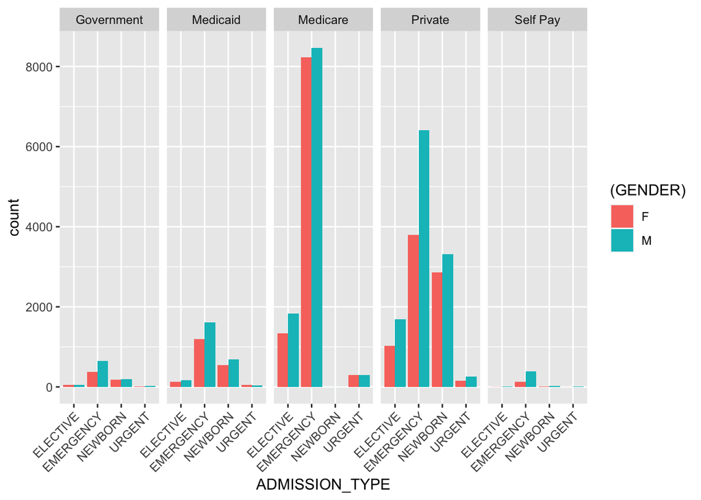

```r
#Figure 5. Visualizing admission types by insurance providers. Very interesting the breakdown of admission types by insurers.
ggplot(data = Demographic, aes(x = ADMISSION_TYPE, fill = (GENDER))) +
    geom_bar(position = "dodge") +
    facet_grid(. ~INSURANCE) + #Split by another variable
    theme(axis.text.x = element_text(angle = 45, hjust = 1))
```

#Creating a new heart failure status variable.

```r
#Creating a new binary column called HF Status indicative of heart failure (HF) or non-HF (noHF)
DIAGNOSES_ICD<- DIAGNOSES_ICD %>%
  mutate(HF_Status = ifelse(ICD9_CODE == 42840 | ICD9_CODE == 42841 | ICD9_CODE == 42842, "HF", "noHF"))

#Pulling ICD codes from Diagnoses table for case/cohort definition.
HF_ICD9 <- filter(DIAGNOSES_ICD, HF_Status == "HF")

#Pulling ICD codes from Diagnoses table for case/cohort definition.
nHF_ICD9 <- filter(DIAGNOSES_ICD, HF_Status == "noHF")

#Table 4. Heart failure vs non-heart failure cohort.
print(table(DIAGNOSES_ICD$HF_Status))
```

```
##
##     HF   noHF
##    362 650685
```

#Creating the heart failure case cohort (NOTEEVENTS_ICD9_HF) #Joining tables NOTEEVENTS data to ICD codes

```r
#Dropping row_id as it is not needed.
library(dplyr)
library(plyr)
HF_ICD9 <- select(HF_ICD9, select = -ROW_ID)
nHF_ICD9 <- select(nHF_ICD9, select = -ROW_ID)

#Defining case cohort
#Joining by unique hospital admission ID aka HADM_ID. That is we are joining a specific ICD9 code of an encounter to that same hospital encounter (HADM_ID) in the NOTEEVENTS
NOTEEVENTS_ICD9_HF <- dplyr::inner_join(NOTEEVENTS, HF_ICD9, by = "HADM_ID")

#Selecting for encounters with discharge summary and echo reports.
NOTEEVENTS_ICD9_HF<- filter(NOTEEVENTS_ICD9_HF, CATEGORY == 'Discharge summary'| CATEGORY == 'Echo' )

#Dropping a few more variables (charttime, storetime and iserror) which are not needed
NOTEEVENTS_ICD9_HF <- dplyr::select(NOTEEVENTS_ICD9_HF, -CHARTTIME, -STORETIME, -ISERROR)
NOTEEVENTS_ICD9_HF<- filter(NOTEEVENTS_ICD9_HF, DESCRIPTION != 'Addendum')

#Characteristics of heart failure cohort
HF_demo <- dplyr::inner_join (Demographic, HF_ICD9, by = "SUBJECT_ID")
```

#Doing more analysis to visualize the data

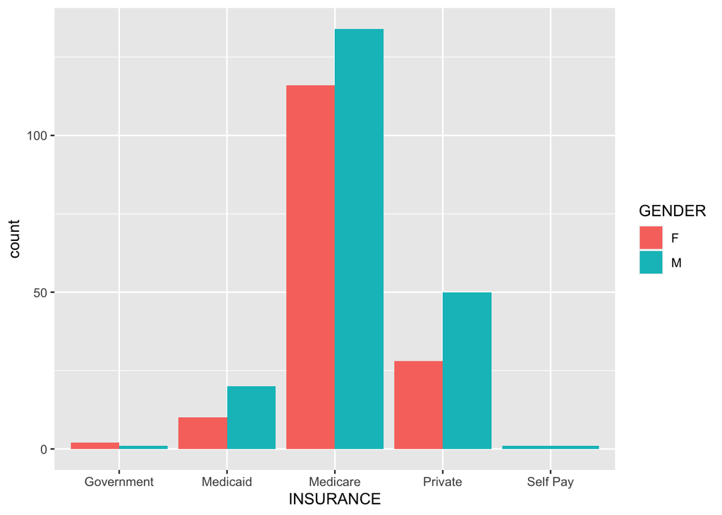

```r
#Figure 6. Visualizing the heart failure cohort
ggplot(data = HF_demo, aes(x =INSURANCE, fill = GENDER)) +
    geom_bar(position = "dodge")
```

```r
    geom_bar()
```

```
## geom_bar: just = 0.5, width = NULL, na.rm = FALSE, orientation = NA
## stat_count: width = NULL, na.rm = FALSE, orientation = NA
## position_stack
```

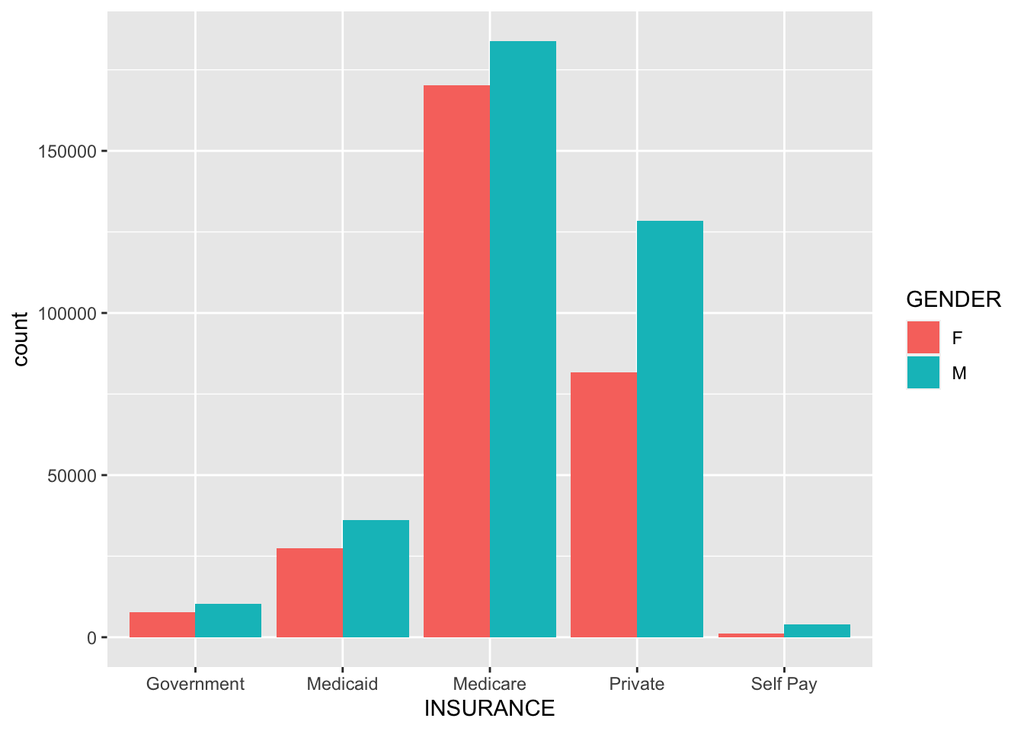

```r
#Obtaining the non-heart failure cohort
#Characteristics of heart failure cohort
nHF_demo <- dplyr::inner_join (Demographic, nHF_ICD9, by = "SUBJECT_ID")

#Figure 7. Visualizing the non heart failure cohort
ggplot(data = nHF_demo, aes(x =INSURANCE, fill = GENDER)) +
    geom_bar(position = "dodge")
```

```r
    geom_bar()
```

```
## geom_bar: just = 0.5, width = NULL, na.rm = FALSE, orientation = NA
## stat_count: width = NULL, na.rm = FALSE, orientation = NA
## position_stack
```

#Logistic regression model with heart failure status (HF_Status) as the outcome. #Assess for significant bivariate relationships using the Pearson’s Chi-square test.

```r
library(modelsummary)
#Joining demographic with heart failure status datables.
Demo_HF_status <- dplyr::inner_join(DIAGNOSES_ICD, Demographic, by = "SUBJECT_ID")

#Converting HF_Status to a factor level
class(Demo_HF_status$HF_Status)
```

```
## [1] "character"
```

```r
Demo_HF_status$HF_Status <- as.factor(Demo_HF_status$HF_Status)
class(Demo_HF_status$HF_Status)
```

```
## [1] "factor"
```

```r
#Logistic regression using HF_status (having heart failure = HF, no heart failure= nHF) and insurance.
summary((glm(HF_Status ~ INSURANCE, data = Demo_HF_status, family = binomial())))
```

```
##
## Call:
## glm(formula = HF_Status ~ INSURANCE, family = binomial(), data = Demo_HF_status)
##
## Deviance Residuals:
##     Min       1Q   Median       3Q      Max
## -4.1711   0.0273   0.0376   0.0376   0.0376
##
## Coefficients:
##                   Estimate Std. Error z value Pr(>|z|)
## (Intercept)         8.6987     0.5774  15.066   <2e-16 ***
## INSURANCEMedicaid  -1.0427     0.6056  -1.722   0.0851 .
## INSURANCEMedicare  -1.4428     0.5808  -2.484   0.0130 *
## INSURANCEPrivate   -0.8011     0.5884  -1.361   0.1734
## INSURANCESelf Pay  -0.1288     1.1548  -0.112   0.9112
## ---
## Signif. codes:  0 '***' 0.001 '**' 0.01 '*' 0.05 '.' 0.1 ' ' 1
##
## (Dispersion parameter for binomial family taken to be 1)
##
##     Null deviance: 6150.0  on 651046  degrees of freedom
## Residual deviance: 6112.9  on 651042  degrees of freedom
## AIC: 6122.9
##
## Number of Fisher Scoring iterations: 11
```

```r
chisq.test(table(Demo_HF_status$HF_Status, Demo_HF_status$INSURANCE))
```

```
##
##  Pearson's Chi-squared test
##
## data:  table(Demo_HF_status$HF_Status, Demo_HF_status$INSURANCE)
## X-squared = 34.074, df = 4, p-value = 7.196e-07
```

```r
#There is a statistically significant association between the Medicare and heart failure status. However, there is not a plausible causative explanation for such finding. I think this is merely an association.


#Logistic regression using HF_status and gender.
summary((glm(HF_Status ~ GENDER, data = Demo_HF_status, family = binomial())))
```

```
##
## Call:
## glm(formula = HF_Status ~ GENDER, family = binomial(), data = Demo_HF_status)
##
## Deviance Residuals:
##     Min       1Q   Median       3Q      Max
## -3.8786   0.0329   0.0337   0.0337   0.0337
##
## Coefficients:
##             Estimate Std. Error z value Pr(>|z|)
## (Intercept)  7.52127    0.08009  93.916   <2e-16 ***
## GENDERM     -0.04818    0.10616  -0.454     0.65
## ---
## Signif. codes:  0 '***' 0.001 '**' 0.01 '*' 0.05 '.' 0.1 ' ' 1
##
## (Dispersion parameter for binomial family taken to be 1)
##
##     Null deviance: 6150.0  on 651046  degrees of freedom
## Residual deviance: 6149.7  on 651045  degrees of freedom
## AIC: 6153.7
##
## Number of Fisher Scoring iterations: 10
```

```r
#Logistic regression using HF_status and admission type to the ICU.
summary((glm(HF_Status ~ ADMISSION_TYPE, data = Demo_HF_status, family = binomial())))
```

```
##
## Call:
## glm(formula = HF_Status ~ ADMISSION_TYPE, family = binomial(),
##     data = Demo_HF_status)
##
## Deviance Residuals:
##     Min       1Q   Median       3Q      Max
## -4.6359   0.0354   0.0354   0.0354   0.0376
##
## Coefficients:
##                         Estimate Std. Error z value Pr(>|z|)
## (Intercept)               7.8378     0.1741  45.016  < 2e-16 ***
## ADMISSION_TYPEEMERGENCY  -0.4639     0.1830  -2.535  0.01123 *
## ADMISSION_TYPENEWBORN     2.9078     1.0150   2.865  0.00417 **
## ADMISSION_TYPEURGENT     -0.5841     0.3372  -1.732  0.08327 .
## ---
## Signif. codes:  0 '***' 0.001 '**' 0.01 '*' 0.05 '.' 0.1 ' ' 1
##
## (Dispersion parameter for binomial family taken to be 1)
##
##     Null deviance: 6150.0  on 651046  degrees of freedom
## Residual deviance: 6097.4  on 651043  degrees of freedom
## AIC: 6105.4
##
## Number of Fisher Scoring iterations: 13
```

```r
chisq.test(table(Demo_HF_status$HF_Status, Demo_HF_status$ADMISSION_TYPE))
```

```
##
##  Pearson's Chi-squared test
##
## data:  table(Demo_HF_status$HF_Status, Demo_HF_status$ADMISSION_TYPE)
## X-squared = 33.068, df = 3, p-value = 3.116e-07
```

```r
#Herein, "Emergency" and "NewBorn" types of admission are statistically associated with heart failure status. Again, I am not fully convinced that there is a plausible causative explanation for such findings. Subsequently, we will see whether variable significance changes when adjusting for other variables.

#Seeing whether variable significance changes when adjusting for other variables.
HF_Status.fit <- glm(HF_Status ~ INSURANCE + ADMISSION_TYPE + GENDER,
                  data = Demo_HF_status,
                  family = binomial())
summary(HF_Status.fit)
```

```
##
## Call:
## glm(formula = HF_Status ~ INSURANCE + ADMISSION_TYPE + GENDER,
##     family = binomial(), data = Demo_HF_status)
##
## Deviance Residuals:
##     Min       1Q   Median       3Q      Max
## -4.8346   0.0298   0.0338   0.0375   0.0423
##
## Coefficients:
##                         Estimate Std. Error z value Pr(>|z|)
## (Intercept)              9.07217    0.60710  14.943   <2e-16 ***
## INSURANCEMedicaid       -1.03773    0.60560  -1.714   0.0866 .
## INSURANCEMedicare       -1.34525    0.58100  -2.315   0.0206 *
## INSURANCEPrivate        -0.88594    0.58859  -1.505   0.1323
## INSURANCESelf Pay       -0.00355    1.15501  -0.003   0.9975
## ADMISSION_TYPEEMERGENCY -0.46532    0.18344  -2.537   0.0112 *
## ADMISSION_TYPENEWBORN    2.61432    1.01808   2.568   0.0102 *
## ADMISSION_TYPEURGENT    -0.60856    0.33735  -1.804   0.0712 .
## GENDERM                 -0.10111    0.10662  -0.948   0.3429
## ---
## Signif. codes:  0 '***' 0.001 '**' 0.01 '*' 0.05 '.' 0.1 ' ' 1
##
## (Dispersion parameter for binomial family taken to be 1)
##
##     Null deviance: 6150.0  on 651046  degrees of freedom
## Residual deviance: 6074.3  on 651038  degrees of freedom
## AIC: 6092.3
##
## Number of Fisher Scoring iterations: 13
```

```r
#As visualized below, type of insurance (Medicare), admission types (Emergency and Newborn) have a statistically significant association with heart failure status even after adjusting for other variables. Again, I am not fully convinced that there is a plausible causative explanation for such findings. As such, I will just note such findings in the conclusion without doing futher exploratory analyses.
```

[output not shown]

#Joining table to create our our overall cohort (both case and control)

```r
#Herein, we want to create a new datable which includes the patient ID, note type (discharge summary, echo report), unique note ID, HADM_ID, column text, HF_case (1 or 0, 1 for case, 0 for cohort), column text.

#Joining Noteevents with ICD9 codes tables
DIAGNOSES_ICD_n <- select(DIAGNOSES_ICD, -ROW_ID)
NOTEEVENTS_ICD9 <- dplyr::inner_join(NOTEEVENTS, DIAGNOSES_ICD_n, by = "HADM_ID")

#Removing obs or noted encounters without associated discharge summaries or echo reports
NOTEEVENTS_ICD9 <- filter(NOTEEVENTS_ICD9, CATEGORY == 'Discharge summary'| CATEGORY == 'Echo') #large dataset as one patient or one admission will have 7-8 different ICD9 codes for billing.

#Turning the HF_status into a factor (0= noHF, 1 = HF)
NOTEEVENTS_ICD9$HF_Status <- ifelse(NOTEEVENTS_ICD9$HF_Status == "HF", 1,0)
table(NOTEEVENTS_ICD9$HF_Status)
```

```
##
##       0       1
## 1171999     823
```